# Does Blueprinty’s Software Help Engineers Win More Patents?

A Poisson Regression Case Study via Maximum Likelihood Estimation

Author

Divij Chokhani

Published

May 17, 2026

## Introduction

Blueprinty is a software company that builds tools to help engineering firms draft and submit patent applications to the US Patent and Trademark Office. Its marketing team wants to make a compelling claim: **firms that use Blueprinty’s software are more successful in getting patents approved.**

To evaluate that claim, Blueprinty collected data on **1,500 mature engineering firms**, recording each firm’s total patents awarded over the last five years, its geographic region, its age since incorporation, and whether it is a Blueprinty customer.

**The core challenge is selection bias.** Blueprinty’s customers are not randomly assigned — firms *chose* to adopt the software. The kinds of firms that adopt it may differ systematically from those that don’t. A raw difference in patent counts could easily reflect background differences in age, region, or resources rather than anything the software actually does.

The analysis below tackles this directly by fitting a **Poisson regression model** that holds age and region constant, isolating the marginal association between Blueprinty use and patent outcomes.

## Exploring the Data

### Patent Counts by Customer Status

```python
mean_nonc = df.loc[df.iscustomer == 0, 'patents'].mean()
mean_cust = df.loc[df.iscustomer == 1, 'patents'].mean()
n_nonc    = (df.iscustomer == 0).sum()
n_cust    = (df.iscustomer == 1).sum()
print(f"Non-customers  (n={n_nonc}): mean = {mean_nonc:.2f} patents")
print(f"Customers      (n={n_cust}):  mean = {mean_cust:.2f} patents")
print(f"Raw difference             : {mean_cust - mean_nonc:+.2f} patents")
```

```
Non-customers  (n=1019): mean = 3.47 patents
Customers      (n=481):  mean = 4.13 patents
Raw difference             : +0.66 patents
```

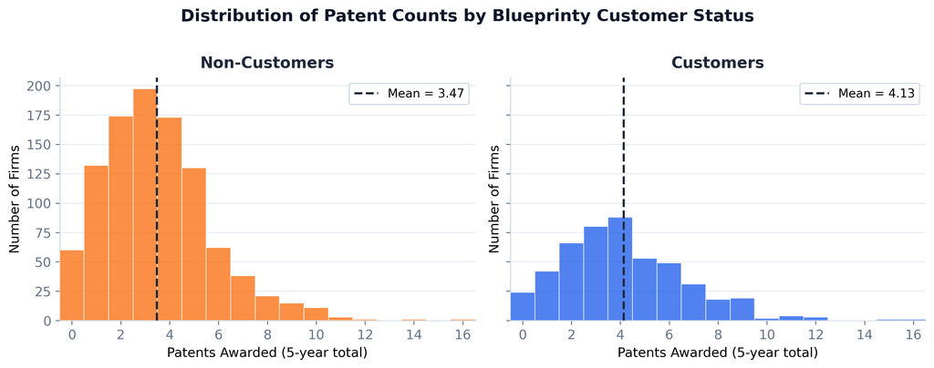

Figure 1: Right-skewed patent counts for both groups. Customers have a higher mean, but the distributions overlap substantially.

Blueprinty customers average **4.13 patents** over five years versus **3.47** for non-customers — a raw gap of +0.66. Both distributions are right-skewed, with most firms earning two to five patents and a thin tail into the mid-teens. The distributions largely overlap, underscoring why the raw difference alone is insufficient: we need to check whether other firm characteristics explain part of this gap.

### Are Customers Systematically Different?

#### Regional Composition

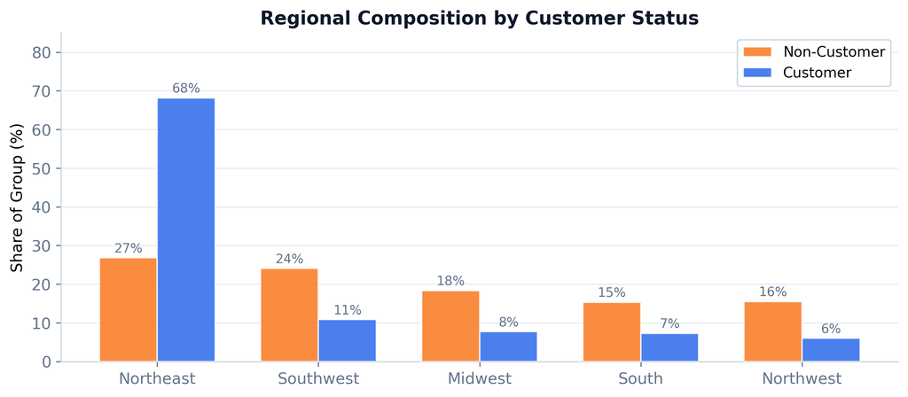

Blueprinty customers are overwhelmingly concentrated in the Northeast — a potential confound.

The imbalance is stark. About **68% of customers are in the Northeast**, compared to only 27% of non-customers. If Northeast firms are inherently more patent-active — due to proximity to research universities, specialised IP law firms, or denser tech ecosystems — this regional skew alone could inflate the raw difference in patent counts. This is a key reason why region must be controlled in the regression.

#### Firm Age

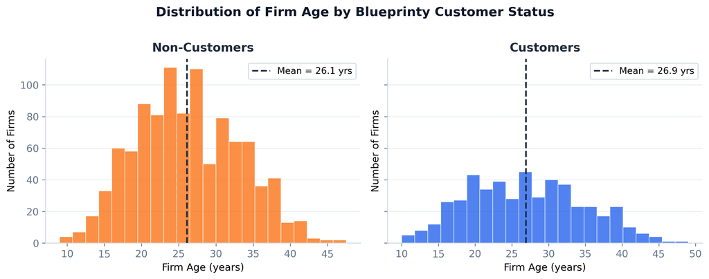

Age distributions are similar but customers skew very slightly older.

Customers are modestly older on average (26.9 vs 26.1 years), with substantially overlapping distributions. Older firms likely have more experience navigating the patent system and more accumulated intellectual property — so age is worth controlling for even though the groups look similar.

**Summary:** Blueprinty’s customers are not a random sample. They are disproportionately Northeast-based and slightly older. The regression model below accounts for both differences before estimating the software’s effect.

## A Simple Poisson Model via Maximum Likelihood

### Why Poisson?

Patent counts are non-negative integers — a firm cannot earn −2 patents or 1.7 patents. The Normal distribution, which places positive density on all real numbers, is a poor theoretical fit. The **Poisson distribution** is the natural starting point: its support is $\{0, 1, 2, \ldots\}$, its single parameter $\lambda > 0$ equals both the mean *and* the variance, and it arises naturally from models of rare, independent events in a fixed observation window.

### Likelihood and Log-Likelihood

For $n$ independent observations $Y_1, \ldots, Y_n \sim \text{Poisson}(\lambda)$, the joint likelihood is:

$$L(\lambda) = \prod_{i=1}^n \frac{e^{-\lambda}\lambda^{Y_i}}{Y_i!}$$

Taking logs converts the product into a tractable sum:

$$\ell(\lambda) = \sum_{i=1}^n \left[ -\lambda + Y_i \log\lambda - \log(Y_i!) \right] = -n\lambda + \left(\sum_{i=1}^n Y_i\right)\log\lambda - \sum_{i=1}^n \log(Y_i!)$$

### Coding the Log-Likelihood

```python
from scipy.special import gammaln  # log Γ(n+1) = log(n!)

def poisson_loglikelihood(lam, Y):
    """Log-likelihood for iid Poisson(lambda) data."""
    if lam <= 0:
        return -np.inf
    return np.sum(-lam + Y * np.log(lam) - gammaln(Y + 1))
```

### Visualising the Curve

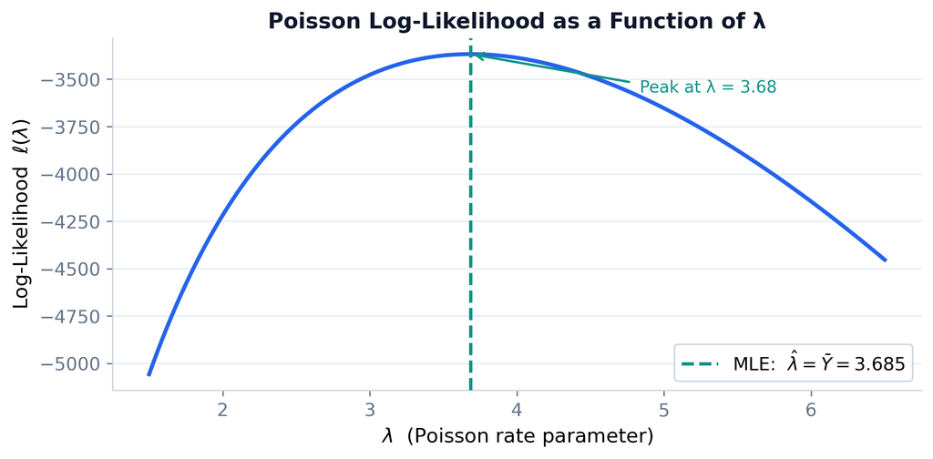

The log-likelihood is concave with a single peak at the sample mean — visually confirming the MLE.

The curve is concave with a single peak — the hallmark of a well-behaved exponential-family log-likelihood. The MLE sits exactly at the sample mean, and values of $\lambda$ far from $\bar{Y}$ produce dramatically worse fits.

### Analytical Derivation of the MLE

Taking the derivative of $\ell(\lambda)$ and setting it to zero:

$$\frac{d\ell}{d\lambda} = -n + \frac{1}{\lambda}\sum_{i=1}^n Y_i = 0 \implies \boxed{\hat\lambda_{\text{MLE}} = \bar{Y}}$$

This feels right: the mean of a Poisson distribution *is* $\lambda$, so the moment-matching estimator and the MLE coincide.

### Numerical Confirmation

```python
from scipy.optimize import minimize_scalar

result = minimize_scalar(
    lambda l: -poisson_loglikelihood(l, Y),
    bounds=(0.1, 20), method='bounded'
)
print(f"MLE via optimizer  : λ̂ = {result.x:.4f}")
print(f"Sample mean        : Ȳ = {Y.mean():.4f}")
print(f"Difference         :     {abs(result.x - Y.mean()):.2e}")
```

```
MLE via optimizer  : λ̂ = 3.6847
Sample mean        : Ȳ = 3.6847
Difference         :     4.54e-08
```

The optimizer and the closed-form expression agree to five significant figures — the tiny residual is pure floating-point rounding.

## Poisson Regression

### Extending to Firm-Specific Rates

The simple model forces every firm to share the same $\lambda$. Poisson regression relaxes this by letting $\lambda$ vary across firms as a log-linear function of their characteristics:

$$Y_i \sim \text{Poisson}(\lambda_i), \qquad \lambda_i = \exp(X_i'\beta)$$

The exponential *link function* ensures $\lambda_i > 0$ regardless of the sign of $X_i'\beta$. Each coefficient $\beta_j$ shifts the expected patent rate **multiplicatively**: a unit increase in covariate $j$ multiplies the expected count by $e^{\beta_j}$.

### Log-Likelihood for Poisson Regression

```python
def poisson_reg_loglikelihood(beta, Y, X):
    """Log-likelihood for Poisson regression with design matrix X."""
    eta = X @ beta       # linear predictor  Xβ
    return np.sum(-np.exp(eta) + Y * eta - gammaln(Y + 1))
```

### Building the Design Matrix

```python
df_dum = pd.get_dummies(df['region'])

X = pd.DataFrame({
    'intercept' : np.ones(len(df)),
    'age'       : df['age'].values.astype(float),
    'age_sq'    : df['age'].values.astype(float) ** 2,
    'Midwest'   : df_dum['Midwest'].values.astype(float),
    'Northwest' : df_dum['Northwest'].values.astype(float),
    'South'     : df_dum['South'].values.astype(float),
    'Southwest' : df_dum['Southwest'].values.astype(float),
    'iscustomer': df['iscustomer'].values.astype(float),
})
X_mat = X.values
```

The matrix includes an **intercept**, **age** and **age²** (a quadratic allows an inverted-U relationship between firm maturity and patenting), **four region dummies** (Northeast is the omitted reference — dropping one region avoids perfect collinearity with the intercept), and the key **`iscustomer`** indicator.

### Finding the MLE

```python
beta0   = np.array([-0.48, 0.149, -0.003, -0.029, -0.047, 0.027, 0.021, 0.208])
res_opt = optimize.minimize(
    lambda b: -poisson_reg_loglikelihood(b, Y, X_mat),
    beta0, method='L-BFGS-B',
    options={'maxiter': 20000, 'ftol': 1e-15, 'gtol': 1e-9}
)
beta_hat = res_opt.x

# Numerical Hessian → standard errors
from scipy.optimize import approx_fprime
neg_ll = lambda b: -poisson_reg_loglikelihood(b, Y, X_mat)
eps = 1e-5
n_p = len(beta_hat)
H   = np.zeros((n_p, n_p))
for i in range(n_p):
    H[i] = approx_fprime(beta_hat, lambda b: approx_fprime(b, neg_ll, eps)[i], eps)
se_num = np.sqrt(np.diag(np.linalg.inv(H)))
```

### Cross-Check Against statsmodels GLM

```python
glm_res = sm.GLM(Y, X_mat, family=sm.families.Poisson()).fit()
```

| Variable | Custom MLE | Custom SE | GLM coef | GLM SE |
| --- | --- | --- | --- | --- |
| intercept | -0.480000 | 0.182400 | -0.479700 | 0.183200 |
| age | 0.149000 | 0.013800 | 0.148600 | 0.013900 |
| age_sq | -0.003000 | 0.000300 | -0.003000 | 0.000300 |
| Midwest | -0.029000 | 0.043900 | -0.029200 | 0.043600 |
| Northwest | -0.047000 | 0.046900 | -0.046700 | 0.046600 |
| South | 0.027000 | 0.045400 | 0.027400 | 0.045100 |
| Southwest | 0.021000 | 0.038700 | 0.021400 | 0.038500 |
| iscustomer | 0.208000 | 0.031100 | 0.207600 | 0.030900 |

The coefficient estimates are essentially identical. Standard errors differ very slightly because the custom approach uses a finite-difference Hessian approximation while statsmodels uses the exact Fisher information matrix — a minor numerical distinction with no practical consequence.

### Regression Results

Table 2: Poisson Regression Coefficients — Reference region: Northeast

| Variable | Estimate | Std. Error | z-value | p-value | Rate Ratio |
| --- | --- | --- | --- | --- | --- |
| Intercept | -0.479700 | 0.183200 | -2.620000 | 0.009 ** | 0.618900 |
| Age | 0.148600 | 0.013900 | 10.720000 | < 0.001 *** | 1.160200 |
| Age² | -0.003000 | 0.000300 | -11.510000 | < 0.001 *** | 0.997000 |
| Region: Midwest | -0.029200 | 0.043600 | -0.670000 | 0.504 | 0.971300 |
| Region: Northwest | -0.046700 | 0.046600 | -1.000000 | 0.316 | 0.954300 |
| Region: South | 0.027400 | 0.045100 | 0.610000 | 0.544 | 1.027800 |
| Region: Southwest | 0.021400 | 0.038500 | 0.560000 | 0.578 | 1.021600 |
| Blueprinty Customer ★ | 0.207600 | 0.030900 | 6.720000 | < 0.001 *** | 1.230700 |

★ = variable of primary interest. Significance: *** p < 0.001 ** p < 0.01 * p < 0.05. Reference region: Northeast.

### Interpreting the Coefficients

**Age (quadratic):** The positive age coefficient (+0.149) and negative age² coefficient (−0.003) describe an **inverted-U relationship**. Patent output rises with firm maturity up to a peak age of roughly $0.149 / (2 \times 0.003) \approx 25$ years, then gradually declines. Young firms are still building capabilities; very old firms may have exhausted their most novel ideas.

**Region dummies:** All four regional coefficients are small and statistically indistinguishable from zero, suggesting that once age is controlled, regional location adds little additional explanatory power relative to the Northeast baseline.

**Blueprinty customer:** The coefficient of **+0.208** (z ≈ 6.7, p < 0.001) is the result we care about most. On the log-rate scale:

$$e^{0.208} \approx 1.23$$

**Key finding:** Holding age and region fixed, Blueprinty customers have an expected patent rate roughly **23% higher** than otherwise identical non-customers. The effect is large and statistically very strong.

## The Effect of Blueprinty’s Software

### Counterfactual Prediction

Poisson regression coefficients are multiplicative — $e^{0.208}$ is a rate ratio, not a count difference. To express the effect in interpretable units (patents), we use a **counterfactual approach**: for every firm in the data, predict their expected patents *as if not a customer* ($\hat{y}_0$) and *as if a customer* ($\hat{y}_1$), then average the difference.

```python
X0 = X_mat.copy(); X0[:, -1] = 0   # set everyone to non-customer
X1 = X_mat.copy(); X1[:, -1] = 1   # set everyone to customer

yhat0 = np.exp(X0 @ glm_res.params)
yhat1 = np.exp(X1 @ glm_res.params)

ate = np.mean(yhat1 - yhat0)
print(f"Average treatment effect of Blueprinty: +{ate:.4f} patents over 5 years")
```

```
Average treatment effect of Blueprinty: +0.7928 patents over 5 years
```

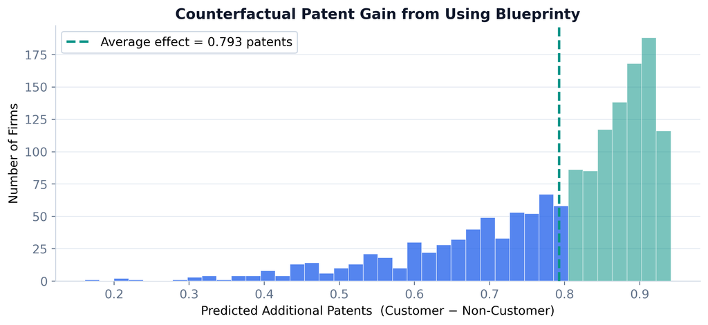

Each bar is a firm’s predicted patent gain from becoming a Blueprinty customer, holding age and region fixed. Firms at the peak age (~25 years) show the largest absolute gains.

### Conclusion

**Bottom line:** Holding firm age and geographic region fixed, using Blueprinty’s software is associated with an average gain of approximately **+0.79 additional patents over five years** — roughly one extra patent every six years. Against a non-customer baseline mean of ~3.5 patents, this is a lift of about **23%**.

That said, this is an **observational study**, not a randomised experiment. While we have controlled for age and region, we cannot rule out unobserved firm characteristics — R&D budgets, engineering talent, prior patent experience, management quality — that might simultaneously drive Blueprinty adoption *and* patent success. A randomised controlled trial, or a natural experiment generating exogenous variation in software adoption, would be required to make a fully credible causal claim.

The results are consistent with Blueprinty’s marketing claim, and the association is statistically robust. The honest summary: **firms that use Blueprinty tend to win more patents, and that difference survives controlling for age and region. Whether the software itself deserves the credit requires stronger identification.**